# Startup Investments

Group 6

Vineeth Penugonda, Sai Rachana Bandi, Chandra Vardhan

04 May 2020

```r
# All Libraries
library(lubridate) # Date
library(binaryLogic) # Binary Encoding

# Visualizations
library(dplyr)
library(ggplot2)
library("tm")
library("SnowballC")
library("wordcloud")
library("RColorBrewer")
library(stringr)
```

# Data Preprocessing

The dataset was downloaded from the following kaggle link: https://www.kaggle.com/arindam235/startup-investments-crunchbase

The dataset related to startup investments in 116 countries has been collected from the CrunchBase database. We considered only the startup companies based in USA. The factors we considered - the type of market, the state, the region the startup belongs to, total funding (in USD), different types of funding – seed, angel, crowdfunding etc., founded date, last funding date, operating status.

### Key Information In The Dataset

**name**: Name of the startup company  
**category_list**: Category the startup belongs to  
**market**: Type of market the startup belongs to  
**funding_total_usd**: Total funding the startup received **status**: Status of the startup – acquired, operational, closed  
**state_code**: State in which the startup was founded in  
**region**: Region in which the startup was founded in  
**city**: City in which the startup was founded in  
**funding_rounds**: Number of funding rounds the startup went through  
**founded_at**: Day on which the startup was founded  
**founded_month**: Month in which the startup was founded  
**founded_quarter**: Quarter in which the startup was founded – Q1, Q2, Q3, Q4 **founded_year**: Year in which the startup was founded  
**first_funding_day**: Day on which the startup started receiving funding  
**first_funding_month**: Month in which the startup started receiving funding  
**first_funding_year**: Year in which the startup started receiving funding  
**last_funding_day**: Day on which the startup stopped receiving funding  
**last_funding_month**: Month in which the startup stopped receiving funding  
**last_funding_year**: Year in which the startup stopped receiving funding  
**seed**: Seed rounds are among the first rounds of funding a company will receive, generally while the company is young and working to gain traction. A seed round typically comes after an angel round (if applicable) and before a company’s Series A round.  
**venture**: Venture funding refers to an investment that comes from a venture capital firm and describes Series A, Series B, and later rounds. This funding type is used for any funding round that is clearly a venture round but where the series has not been specified.  
**equity_crowdfunding**: Equity crowdfunding platforms allow individual users to invest in companies in exchange for equity. Typically, on these platforms the investors invest small amounts of money, though syndicates are formed to allow an individual to take a lead on evaluating an investment and pooling funding from a group of individual investors. **undisclosed**: Undisclosed amount on the last funding date.  
**convertible_note**: A convertible note is an ‘in-between’ round funding to help companies hold over until they want to raise their next round of funding. When they raise the next round, this note ‘converts’ with a discount at the price of the new round. You will typically see convertible notes after a company raises, for example, a Series A round but does not yet want to raise a Series B round.  
**debt_financing**: In a debt round, an investor lends money to a company, and the company promises to repay the debt with added interest.  
**angel**: An angel round is typically a small round designed to get a new company off the ground. Investors in an angel round include individual angel investors, angel investor groups, friends, and family.  
**grant**: A grant is when a company, investor, or government agency provides capital to a company without taking an equity stake in the company.  
**private_equity**: A private equity round is led by a private equity firm or a hedge fund and is a late stage round. It is a less risky investment because the company is more firmly established, and the rounds are typically upwards of $50M. **post_ipo_equity**: A post-IPO equity round takes place when firms invest in a company after the company has already gone public.  
**post_ipo_debt**: A post-IPO debt round takes place when firms loan a company money after the company has already gone public. Similar to debt financing, a company will promise to repay the principal as well as added interest on the debt. **secondary_market**: A secondary market transaction is a fundraising event in which one investor purchases shares of stock in a company from other, existing shareholders rather than from the company directly. These transactions often occur when a private company becomes highly valuable and early stage investors or employees want to earn a profit on their investment, and these transactions are rarely announced or publicized.  
**product_crowdfunding**: In a product crowdfunding round, a company will provide its product, which is often still in development, in exchange for capital. This kind of round is also typically completed on a funding platform. **round_A**: Round A is a funding round for earlier stage companies and range on average between $1M–$30M.  
**round_B**: Round B is a funding round for earlier stage companies and range on average between $1M–$30M.  
**round_C**: Round C is a funding round for later stage and more established companies. These rounds are usually $10M+ and are often much larger. **round_D**: Round D is a funding round for later stage and more established companies. These rounds are usually $10M+ and are often much larger.  
**round_E**: Round E is a funding round for later stage and more established companies. These rounds are usually $10M+ and are often much larger.  
**round_F**: Round F is a funding round for later stage and more established companies. These rounds are usually $10M+ and are often much larger.  
**round_G**: Round G is a funding round for later stage and more established companies. These rounds are usually $10M+ and are often much larger.  
**round_H**: Round H is a funding round for later stage and more established companies. These rounds are usually $10M+ and are often much larger.  
**post_success**: Indicates if the startup was successful or not successful based on the rules mentioned above.

```r
dat <- read.csv("/Users/vineethpenugonda/Documents/Academics/Masters/Semester IV/IST 5535/Projects/StartUps_Investments_ML/Dataset/US_StartUps_Investments_Data.csv", na.strings = c("", "NA"), stringsAsFactors = FALSE)
head(dat)
```

|  | X | permalink | name | homepage_url | category_list | market | funding_total_usd | status | country_code | state_code | region | city | funding_rounds | founded_at | founded_month | founded_quarter | founded_year | first_funding_at | last_funding_at | seed | venture | equity_crowdfunding | undisclosed | convertible_note | debt_financing | angel | grant | private_equity | post_ipo_equity | … |
| --- | --- | --- | --- | --- | --- | --- | --- | --- | --- | --- | --- | --- | --- | --- | --- | --- | --- | --- | --- | --- | --- | --- | --- | --- | --- | --- | --- | --- | --- | --- |
| 1 | 0 | /organization/waywire | #waywire | http://www.waywire.com | \|Entertainment\|Politics\|Social Media\|News\| | News | 17,50,000 | acquired | USA | NY | New York City | New York | 1 | 2012-06-01 | 2012-06 | 2012-Q2 | 2012 | 2012-06-30 | 2012-06-30 | 1750000 | 0e+00 | 0 | 0 | 0 | 0 | 0 | 0 | 0 | 0 | … |
| 2 | 1 | /organization/tv-communications | &TV Communications | http://enjoyandtv.com | \|Games\| | Games | 40,00,000 | operating | USA | CA | Los Angeles | Los Angeles | 2 | NA | NA | NA | NA | 2010-06-04 | 2010-09-23 | 0 | 4e+06 | 0 | 0 | 0 | 0 | 0 | 0 | 0 | 0 | … |
| 3 | 2 | /organization/r-ranch-and-mine | -R- Ranch and Mine | NA | \|Tourism\|Entertainment\|Games\| | Tourism | 60,000 | operating | USA | TX | Dallas | Fort Worth | 2 | 2014-01-01 | 2014-01 | 2014-Q1 | 2014 | 2014-08-17 | 2014-09-26 | 0 | 0e+00 | 60000 | 0 | 0 | 0 | 0 | 0 | 0 | 0 | … |
| 4 | 3 | /organization/club-domains | .Club Domains | http://nic.club/ | \|Software\| | Software | 70,00,000 | NA | USA | FL | Ft. Lauderdale | Oakland Park | 1 | 2011-10-10 | 2011-10 | 2011-Q4 | 2011 | 2013-05-31 | 2013-05-31 | 0 | 7e+06 | 0 | 0 | 0 | 0 | 0 | 0 | 0 | 0 | … |
| 5 | 4 | /organization/004-technologies | 004 Technologies | http://004gmbh.de/en/004-interact | \|Software\| | Software | - | operating | USA | IL | Springfield, Illinois | Champaign | 1 | 2010-01-01 | 2010-01 | 2010-Q1 | 2010 | 2014-07-24 | 2014-07-24 | 0 | 0e+00 | 0 | 0 | 0 | 0 | 0 | 0 | 0 | 0 | … |
| 6 | 5 | /organization/1-4-all | 1-4 All | NA | \|Entertainment\|Games\|Software\| | Software | - | operating | USA | NC | NC - Other | Connellys Springs | 1 | NA | NA | NA | NA | 2013-04-21 | 2013-04-21 | 0 | 0e+00 | 0 | 0 | 0 | 0 | 0 | 0 | 0 | 0 | … |

On initial observation, the dataset downloaded from Kaggle had a lot of missing data. So, we removed rows which had missing data in one or more columns.

```r
# Replacing commas in the column - funding_total_usd
dat$funding_total_usd <- as.numeric(gsub(",","",dat$funding_total_usd))
```

The values in the column “funding_total_usd” had commas. We removed commas for the values.

```r
# Remove rows with NAs
dat <- dat[complete.cases(dat),]
```

```r
# Remove trailing spaces in column - market
dat$market <- trimws(dat$market, which = c("both"))
```

The **market** column had left and right trailing spaces for each keyword. So, we trimmed it using trimws() function.

```r
# Remove country_code, homepage_URL, X and permalink
dat$homepage_url <- NULL
dat$X <- NULL
dat$permalink <- NULL
dat$country_code <- NULL
```

We didn’t require **homepage URL of the startup company**, **X which is the ID**, **permalink - permanent link in the crunchbase**, **country code**. We are considering only startups in United States of America (USA).

```r
# Strip values in columns
# Month
dat$founded_month = substring(dat$founded_month,6)
dat$founded_month = as.numeric(dat$founded_month)

# Quarter
dat$founded_quarter = substring(dat$founded_quarter,6)

# YY/MM/DD. We only need the day.
dat$founded_at = substring(dat$founded_at,9)
dat$founded_at = as.numeric(dat$founded_at)
```

We observed that the values in the **founded_month** column were in **Year-Month**. Since we needed only the month we removed the year from those values. It was a similar case for **founded_quarter** column.

**founded_at** is the day in the YY/MM/DD format. So we removed year and month information from the values to just get the day(dd) information.

```r
# Date DataType
dat$first_funding_at <- as.Date(dat$first_funding_at)
dat$last_funding_at <- as.Date(dat$last_funding_at)
```

```r
# Separate date into three columns
dat$first_funding_day <- day(ymd(dat$first_funding_at))
dat$first_funding_month <- month(ymd(dat$first_funding_at))
dat$first_funding_year <- year(ymd(dat$first_funding_at))

dat$last_funding_day <- day(ymd(dat$last_funding_at))
dat$last_funding_month <- month(ymd(dat$last_funding_at))
dat$last_funding_year <- year(ymd(dat$last_funding_at))

# Remove Funding Dates
dat$first_funding_at <- NULL
dat$last_funding_at <- NULL
```

**first_funding_at** and **last_funding_at** are in YY/MM/DD format. We split the dates into three columns - **first_funding_day** (DD), **first_funding_month** (MM),**first_funding_year** (YY).

```r
# Create new column: Success or not Success
# Acquired, post_ipo_equity or post_ipo_equity and Acquired

dat$post_success <- ifelse(dat$status=="acquired", 1,
               ifelse(dat$post_ipo_equity > 0, 1,
                      ifelse((dat$status=="acquired") && (dat$post_ipo_equity > 0), 1,
                                    0  ))) # all other values map to 0

dat$post_success <- factor(dat$post_success)
```

Both an IPO (Initial Public Offering) and a process of M&A (Mergers & Acquisitions) are the critical events that classify a start-up as successful.

We created the “post_success” column which indicates if the startup was successful or not successful based on these rules – if the status of the company is “acquired” or if the post IPO equity is greater than 0 or if the status of the company is “acquired” and the post IPO equity is greater than 0.

```r
str(dat)
```

```
## 'data.frame':    18280 obs. of  41 variables:
##  $ name                : chr  "#waywire" "1-800-DOCTORS" "10-20 Media" "1000 Corks" ...
##  $ category_list       : chr  "|Entertainment|Politics|Social Media|News|" "|Health and Wellness|" "|E-Commerce|" "|Search|" ...
##  $ market              : chr  "News" "Health and Wellness" "E-Commerce" "Search" ...
##  $ funding_total_usd   : num  1750000 1750000 2050000 40000 2535000 ...
##  $ status              : chr  "acquired" "operating" "operating" "operating" ...
##  $ state_code          : chr  "NY" "NJ" "MD" "OR" ...
##  $ region              : chr  "New York City" "Newark" "Baltimore" "Portland, Oregon" ...
##  $ city                : chr  "New York" "Iselin" "Woodbine" "Lake Oswego" ...
##  $ funding_rounds      : num  1 1 4 1 2 6 1 2 1 1 ...
##  $ founded_at          : num  1 1 1 1 1 1 4 16 1 1 ...
##  $ founded_month       : num  6 1 1 1 7 1 7 9 1 4 ...
##  $ founded_quarter     : chr  "Q2" "Q1" "Q1" "Q1" ...
##  $ founded_year        : num  2012 1984 2001 2008 2010 ...
##  $ seed                : num  1750000 0 0 40000 15000 0 420000 750000 0 50000 ...
```

[output cut: 27 more lines]

```r
# Saving file
write.csv(dat,'Data_Cleansed.csv')
saveRDS(dat, file = "Data_Cleansed.rds")
```

### Binary Encoding

There are more than 32 markets, regions and states. We binary encoded the values in *market*, *region*, *state_code*. Then, digits from that binary string are split into separate columns. This is useful for machine learning. Better encoding of categorical data can mean better model performance.

```r
# Function for Binary Encoding

encode_binary <- function(x, order = unique(x), name = "v_") {
  x <- as.numeric(factor(x, levels = order, exclude = NULL))
  x2 <- as.binary(x)
  maxlen <- max(sapply(x2, length))
  x2 <- lapply(x2, function(y) {
    l <- length(y)
    if (l < maxlen) {
      y <- c(rep(0, (maxlen - l)), y)
    }
    y
  })
  d <- as.data.frame(t(as.data.frame(x2)))
  rownames(d) <- NULL
  colnames(d) <- paste0(name, 1:maxlen)
  d
}
```

```r
# dat -> Visualizations
# filter_data -> ML

new_df <- cbind(dat, encode_binary(dat[["market"]], name = "market_"))

new_df <- cbind(new_df, encode_binary(dat[["region"]], name = "region_"))

new_df <- cbind(new_df, encode_binary(dat[["state_code"]], name = "state_code_"))

saveRDS(new_df, file = "Data_Cleansed_Encoded.rds")
```

### Filtering and Factorizing

We selected data from year 1990 until 2014. We converted all the categorical variables to factors. We also converted the data types from “num” to “logical” (boolean) for the binary encoded columns.

```r
# Filter the data and Factorize it!

filter_data <- new_df[ which(new_df$founded_year >= 1990), ]

# Datatypes
# Categorical Variables:  name, category_list, market, status, state_code, region, city, founded_at, founded_month, founded_quarter,
#                         founded_year, first_funding_day, first_funding_month, first_funding_year, last_funding_day, last_funding_month,
#                         last_funding_year

filter_data$name <- NULL
filter_data$category_list<- NULL
filter_data$market<- NULL

filter_data$status<-factor(filter_data$status)

filter_data$state_code<- NULL
filter_data$region<- NULL
filter_data$city<- NULL

filter_data$founded_at<-factor(filter_data$founded_at)
filter_data$founded_month<-factor(filter_data$founded_month)
filter_data$founded_quarter<-factor(filter_data$founded_quarter)
filter_data$founded_year<-factor(filter_data$founded_year)
filter_data$first_funding_day<-factor(filter_data$first_funding_day)
filter_data$first_funding_month<-factor(filter_data$first_funding_month)
filter_data$first_funding_year<-factor(filter_data$first_funding_year)
filter_data$last_funding_day<-factor(filter_data$last_funding_day)
filter_data$last_funding_month<-factor(filter_data$last_funding_month)
filter_data$last_funding_year<-factor(filter_data$last_funding_year)

filter_data$market_1 <- as.logical(filter_data$market_1)
filter_data$market_2 <- as.logical(filter_data$market_2)
filter_data$market_3 <- as.logical(filter_data$market_3)
filter_data$market_4 <- as.logical(filter_data$market_4)
filter_data$market_5 <- as.logical(filter_data$market_5)
filter_data$market_6 <- as.logical(filter_data$market_6)
filter_data$market_7 <- as.logical(filter_data$market_7)
filter_data$market_8 <- as.logical(filter_data$market_8)
filter_data$market_9 <- as.logical(filter_data$market_9)
filter_data$market_10 <- as.logical(filter_data$market_10)

filter_data$region_1 <- as.logical(filter_data$region_1)
filter_data$region_2 <- as.logical(filter_data$region_2)
filter_data$region_3 <- as.logical(filter_data$region_3)
filter_data$region_4 <- as.logical(filter_data$region_4)
filter_data$region_5 <- as.logical(filter_data$region_5)
filter_data$region_6 <- as.logical(filter_data$region_6)
filter_data$region_7 <- as.logical(filter_data$region_7)
filter_data$region_8 <- as.logical(filter_data$region_8)

filter_data$state_code_1 <- as.logical(filter_data$state_code_1)
filter_data$state_code_2 <- as.logical(filter_data$state_code_2)
filter_data$state_code_3 <- as.logical(filter_data$state_code_3)
filter_data$state_code_4 <- as.logical(filter_data$state_code_4)
filter_data$state_code_5 <- as.logical(filter_data$state_code_5)
filter_data$state_code_6 <- as.logical(filter_data$state_code_6)

saveRDS(filter_data, file="Data_CE_Filtered.rds")

str(filter_data)
```

```
## 'data.frame':    17784 obs. of  59 variables:
##  $ funding_total_usd   : num  1750000 2050000 40000 2535000 4962651 ...
##  $ status              : Factor w/ 3 levels "acquired","closed",..: 1 3 3 1 3 3 1 3 2 3 ...
##  $ funding_rounds      : num  1 4 1 2 6 1 2 1 1 1 ...
##  $ founded_at          : Factor w/ 31 levels "1","2","3","4",..: 1 1 1 1 1 4 16 1 1 1 ...
##  $ founded_month       : Factor w/ 12 levels "1","2","3","4",..: 6 1 1 7 1 7 9 1 4 1 ...
##  $ founded_quarter     : Factor w/ 4 levels "Q1","Q2","Q3",..: 2 1 1 3 1 3 3 1 2 1 ...
##  $ founded_year        : Factor w/ 25 levels "1990","1991",..: 23 12 19 21 19 25 22 11 20 23 ...
##  $ seed                : num  1750000 0 40000 15000 0 420000 750000 0 50000 0 ...
##  $ venture             : num  0 0 0 2520000 3814772 ...
##  $ equity_crowdfunding : num  0 0 0 0 0 0 0 0 0 0 ...
##  $ undisclosed         : num  0 0 0 0 0 0 0 0 0 0 ...
##  $ convertible_note    : num  0 0 0 0 0 0 0 0 0 0 ...
##  $ debt_financing      : num  0 2050000 0 0 1147879 ...
##  $ angel               : num  0 0 0 0 0 0 0 0 0 0 ...
```

[output cut: 45 more lines]

Finally, we have no null values in the dataset! We changed the data type of each column for further analysis.

# Visualizations

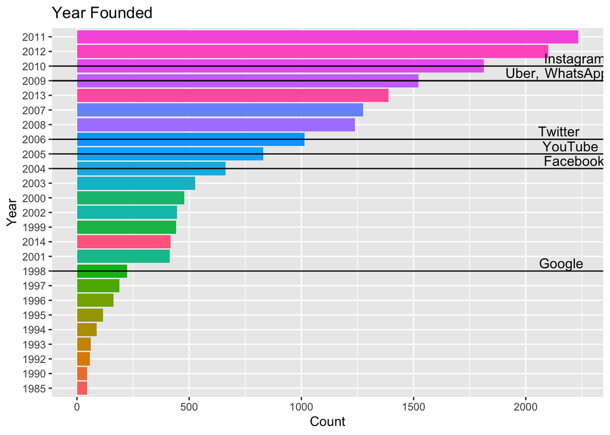

```r
# Founding year
viz_data <- dat
viz_data$founded_year <- factor(viz_data$founded_year)

viz_data %>% count(founded_year)%>% arrange(-n) %>% head(25) %>%
  ggplot(aes(reorder(founded_year, n), n)) + geom_col(aes(fill=founded_year)) + coord_flip() +
  theme(legend.position="none") +
  ggtitle("Year Founded") + xlab("Year") + ylab("Count") +
  geom_vline(aes(xintercept = founded_year), data = viz_data %>% filter(name == "Facebook")) +
  geom_text(aes(x = founded_year, y=2000, label = "Facebook"), data = viz_data %>% filter(name == "Facebook"), size=4, vjust=-0.3, hjust=-0.3) +
  geom_vline(aes(xintercept = founded_year), data = viz_data %>% filter(name == "Twitter")) +
  geom_text(aes(x = founded_year, y=2000, label = "Twitter"), data = viz_data %>% filter(name == "Twitter"), size=4, vjust=-0.3, hjust=-0.3) +
  geom_vline(aes(xintercept = founded_year), data = viz_data %>% filter(name == "Google")) +
  geom_text(aes(x = founded_year, y=2000, label = "Google"), data = viz_data %>% filter(name == "Google"), size=4, vjust=-0.3, hjust=-0.3) +
  geom_vline(aes(xintercept = founded_year), data = viz_data %>% filter(name == "YouTube")) +
  geom_text(aes(x = founded_year, y=2000, label = "YouTube"), data = viz_data %>% filter(name == "YouTube"), size=4, vjust=-0.3, hjust=-0.3) +
  geom_vline(aes(xintercept = founded_year), data = viz_data %>% filter(name == "Instagram")) +
  geom_text(aes(x = founded_year, y=2000, label = "Instagram"), data = viz_data %>% filter(name == "Instagram"), size=4, vjust=-0.3, hjust=-0.3) +
  geom_vline(aes(xintercept = founded_year), data = viz_data %>% filter(name == "Uber")) +
  geom_text(aes(x = founded_year, y=2000, label = "Uber,"), data = viz_data %>% filter(name == "Uber"), size=4, vjust=-0.3, hjust=0.6) +
  geom_vline(aes(xintercept = founded_year), data = viz_data %>% filter(name == "WhatsApp")) +
  geom_text(aes(x = founded_year, y=2000, label = "WhatsApp"), data = viz_data %>% filter(name == "WhatsApp"), size=4, vjust=-0.3, hjust=-0.3)
```

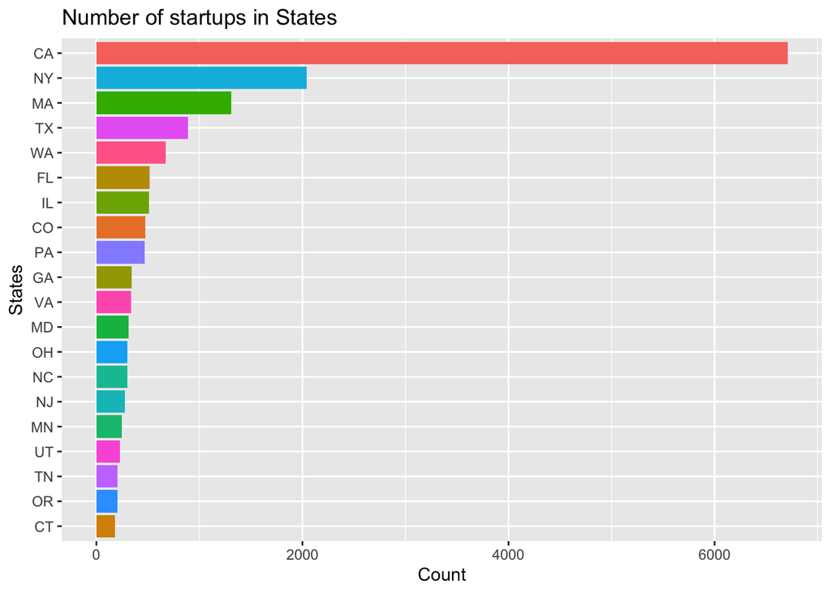

```r
# State Code
dat %>% count(state_code)%>% arrange(-n) %>% head(20) %>%
  ggplot(aes(reorder(state_code, n), n)) + geom_col(aes(fill=state_code)) + coord_flip() +
  theme(legend.position="none") +
  ggtitle("Number of startups in States") + xlab("States") + ylab("Count")
```

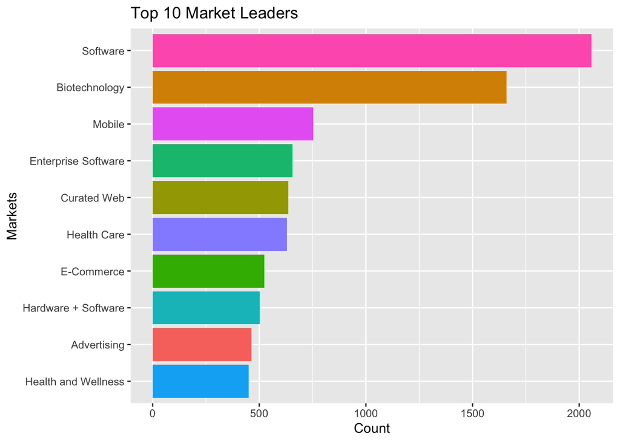

```r
# Top 10 market leaders
dat %>% filter(market!="") %>% count(market)%>% arrange(-n) %>% head(10) %>%
 ggplot(aes(reorder(market, n), n)) + geom_col(aes(fill=market)) + coord_flip() +
 theme(legend.position="none") +
 ggtitle("Top 10 Market Leaders") + xlab("Markets") + ylab("Count")
```

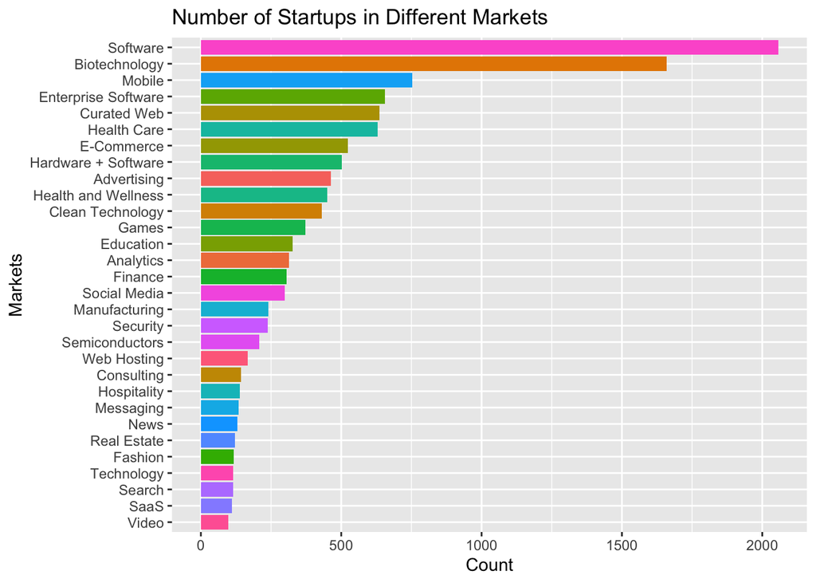

```r
# Markets
dat %>% count(market)%>% arrange(-n) %>% head(30) %>%
  ggplot(aes(reorder(market, n), n)) + geom_col(aes(fill=market)) + coord_flip() +
  theme(legend.position="none") +
  ggtitle("Number of Startups in Different Markets") + xlab("Markets") + ylab("Count")
```

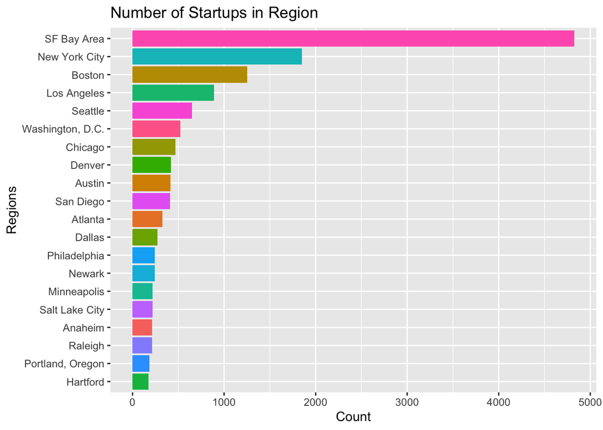

```r
# Regions
dat %>% count(region)%>% arrange(-n) %>% head(20) %>%
  ggplot(aes(reorder(region, n), n)) + geom_col(aes(fill=region)) + coord_flip() +
  theme(legend.position="none") +
  ggtitle("Number of Startups in Region") + xlab("Regions") + ylab("Count")
```

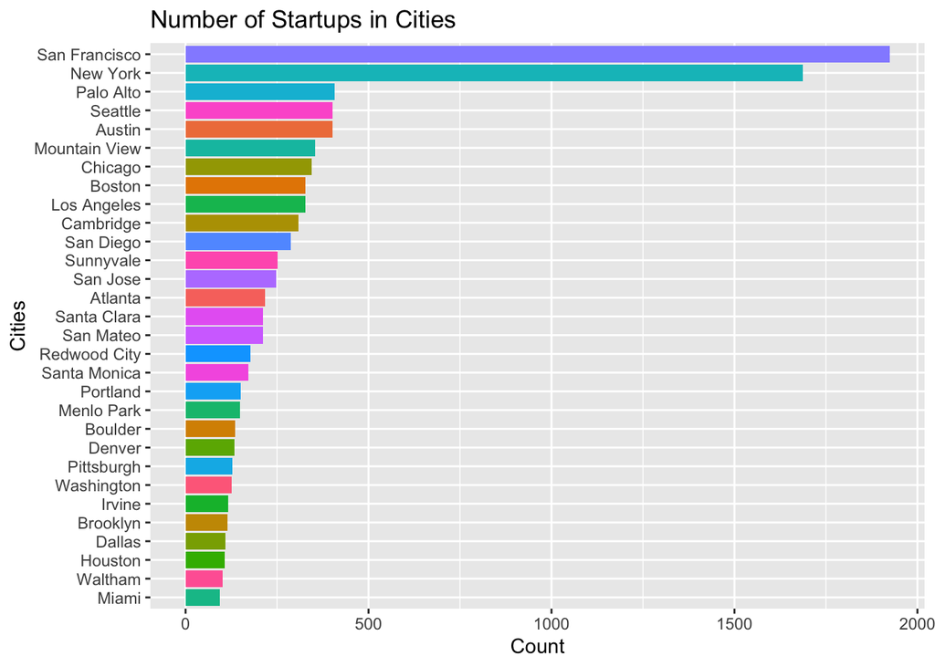

```r
# Cities
dat %>% count(city)%>% arrange(-n) %>% head(30) %>%
  ggplot(aes(reorder(city, n), n)) + geom_col(aes(fill=city)) + coord_flip() +
  theme(legend.position="none") +
  ggtitle("Number of Startups in Cities") + xlab("Cities") + ylab("Count")
```

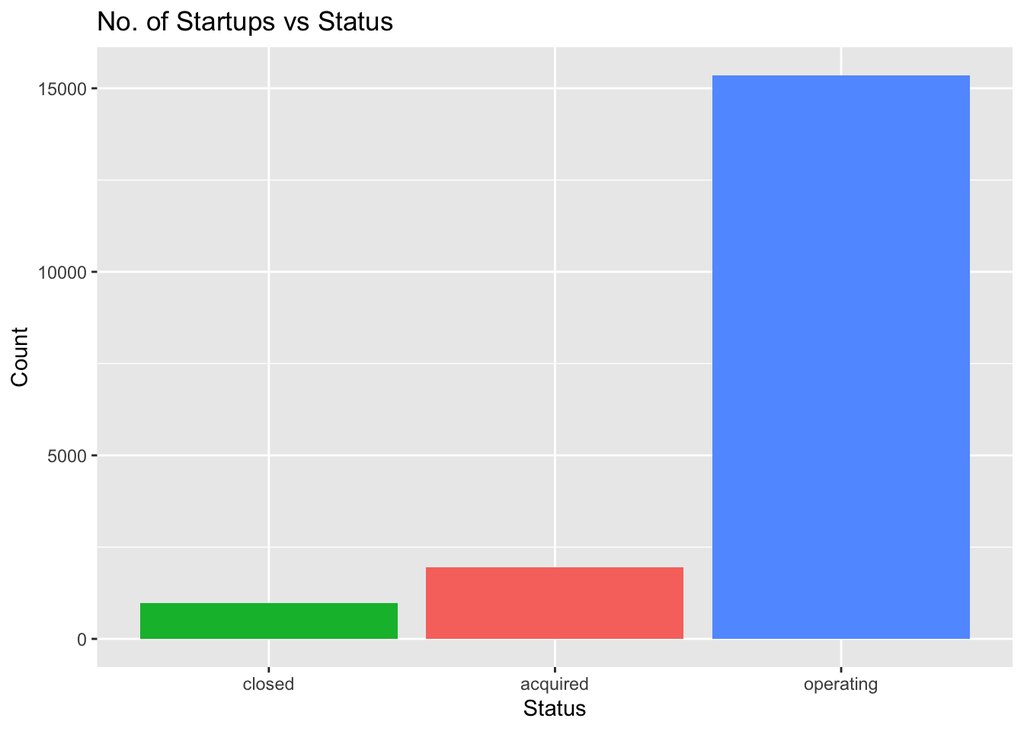

```r
# No. of Startups vs Status
dat %>% count(status)%>% arrange(-n) %>%
  ggplot(aes(reorder(status, n), n)) + geom_col(aes(fill=status))  +
  theme(legend.position="none") +
  ggtitle("No. of Startups vs Status") + xlab("Status") + ylab("Count")
```

```r
docs <- apply(dat['category_list'], 2, function(y) str_sub(y, 2, -2))
docs <- apply(docs, 2, function(y) unlist(strsplit(y, "\\|")))
docs <- Corpus(VectorSource(docs))
```

```r
# Convert the text to lower case
docs <- tm_map(docs, content_transformer(tolower))
# Remove numbers
docs <- tm_map(docs, removeNumbers)
# Remove english common stopwords
docs <- tm_map(docs, removeWords, stopwords("english"))
# Remove your own stop word
# specify your stopwords as a character vector
#docs <- tm_map(docs, removeWords, c("blabla1", "blabla2"))
# Remove punctuations
docs <- tm_map(docs, removePunctuation)
# Eliminate extra white spaces
#docs <- tm_map(docs, stripWhitespace)
# Text stemming
# docs <- tm_map(docs, stemDocument)
```

```r
dtm <- TermDocumentMatrix(docs)
m <- as.matrix(dtm)
v <- sort(rowSums(m),decreasing=TRUE)
d <- data.frame(word = names(v),freq=v)
head(d, 10)
```

|  | word | freq |
| --- | --- | --- |
| software | software | 5147 |
| mobile | mobile | 2292 |
| biotechnology | biotechnology | 1852 |
| web | web | 1836 |
| media | media | 1765 |
| social | social | 1749 |
| health | health | 1603 |
| enterprise | enterprise | 1255 |
| curated | curated | 1211 |
| advertising | advertising | 1110 |

[figure not shown]

```r
set.seed(1234)
wordcloud(words = d$word, freq = d$freq, min.freq = 1,
          max.words=200, random.order=FALSE, rot.per=0.35,
          colors=brewer.pal(8, "Dark2"))
```

```r
#Explore frequent terms and their associations
#You can have a look at the frequent terms in the term-document matrix as follow. In the example below we want to find words that occur at least four times :
findFreqTerms(dtm, lowfreq = 4)
```

```
##   [1] "entertainment"      "politics"           "media"
##   [4] "social"             "news"               "health"
##   [7] "wellness"           "ecommerce"          "search"
##  [10] "curated"            "web"                "care"
##  [13] "information"        "technology"         "analytics"
##  [16] "software"           "biotechnology"      "devices"
##  [19] "medical"            "pharmaceuticals"    "personalization"
##  [22] "manufacturing"      "graph"              "interest"
##  [25] "advertising"        "sports"             "real"
##  [28] "time"               "video"              "games"
##  [31] "shopping"           "cosmetics"          "personal"
##  [34] "lifestyle"          "fashion"            "services"
##  [37] "mobile"             "big"                "data"
##  [40] "enterprise"         "commerce"           "art"
##  [43] "non"                "profit"             "fundraising"
```

[output cut: 168 more lines]

```r
findAssocs(dtm, terms = "health", corlimit = 0.3)
```

```
## $health
##     care wellness
##     0.72     0.63
```

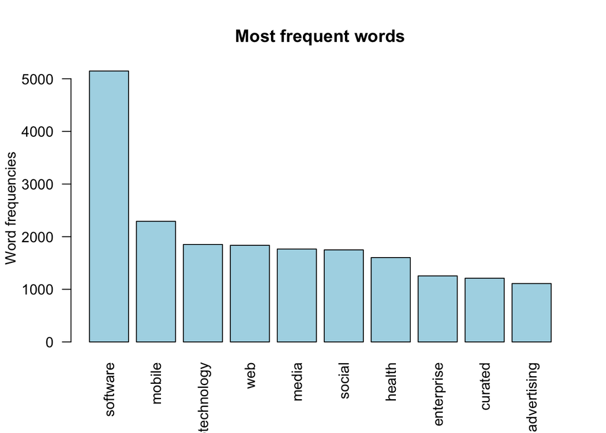

```r
#Plot word frequencies
barplot(d[1:10,]$freq, las = 2, names.arg = d[1:10,]$word,
        col ="lightblue", main ="Most frequent words",
        ylab = "Word frequencies")
```

```r
dat %>%
  group_by(post_success) %>%
  top_n(10, market)
```

| name | category_list | market | funding_total_usd | status | state_code | region | city | funding_rounds | founded_at | founded_month | founded_quarter | founded_year | seed | venture | equity_crowdfunding | undisclosed | convertible_note | debt_financing | angel | grant | private_equity | post_ipo_equity | post_ipo_debt | secondary_market | product_crowdfunding | round_A | round_B | round_C | round_D | … |
| --- | --- | --- | --- | --- | --- | --- | --- | --- | --- | --- | --- | --- | --- | --- | --- | --- | --- | --- | --- | --- | --- | --- | --- | --- | --- | --- | --- | --- | --- | --- |
| AeroScout | \|Wireless\|RFID\|Mobile\| | Wireless | 28000000 | acquired | CA | SF Bay Area | Redwood City | 2 | 1 | 1 | Q1 | 1999 | 0 | 28000000 | 0 | 0 | 0 | 0 | 0 | 0 | 0 | 0 | 0 | 0 | 0 | 0 | 0 | 0 | 12000000 | … |
| Airbiquity | \|Wireless\|Automotive\|Software\| | Wireless | 35419873 | operating | WA | Seattle | Seattle | 2 | 1 | 1 | Q1 | 1997 | 0 | 35419873 | 0 | 0 | 0 | 0 | 0 | 0 | 0 | 0 | 0 | 0 | 0 | 0 | 0 | 0 | 0 | … |
| AirPatrol Corporation | \|Wireless\|Mobile Security\|Location Based Services\|Mobility\|Mobile\| | Wireless | 3675000 | acquired | MD | Baltimore | Columbia | 1 | 1 | 1 | Q1 | 2006 | 0 | 0 | 0 | 0 | 0 | 3675000 | 0 | 0 | 0 | 0 | 0 | 0 | 0 | 0 | 0 | 0 | 0 | … |
| AirTight Networks | \|Wireless\|Security\| | Wireless | 46750000 | operating | CA | SF Bay Area | Mountain View | 4 | 1 | 1 | Q1 | 2002 | 0 | 46750000 | 0 | 0 | 0 | 0 | 0 | 0 | 0 | 0 | 0 | 0 | 0 | 10250000 | 12000000 | 14500000 | 10000000 | … |
| Altierre | \|Wireless\|Education\|Mobile\| | Wireless | 85100000 | operating | CA | SF Bay Area | San Jose | 6 | 1 | 1 | Q1 | 2003 | 0 | 85100000 | 0 | 0 | 0 | 0 | 0 | 0 | 0 | 0 | 0 | 0 | 0 | 13000000 | 17000000 | 30000000 | 0 | … |
| Avnera | \|Creative\|Messaging\|Audio\|Wireless\|Semiconductors\| | Wireless | 77447377 | operating | OR | Portland, Oregon | Beaverton | 9 | 1 | 1 | Q1 | 2004 | 0 | 74788123 | 0 | 0 | 0 | 2659254 | 0 | 0 | 0 | 0 | 0 | 0 | 0 | 15300000 | 12000000 | 14700000 | 10000000 | … |
| Benu Networks | \|Mobile Infrastructure\|Internet Infrastructure\|Telecommunications\|Wireless\|Mobile\| | Wireless | 59330248 | operating | MA | Boston | Billerica | 3 | 1 | 1 | Q1 | 2010 | 0 | 54300000 | 0 | 0 | 0 | 0 | 0 | 0 | 5030248 | 0 | 0 | 0 | 0 | 0 | 26600000 | 27700000 | 0 | … |
| BitWave | \|Wireless\|Mobile\| | Wireless | 27750000 | operating | MA | Boston | Lowell | 4 | 1 | 1 | Q1 | 2004 | 0 | 24500000 | 0 | 0 | 0 | 3250000 | 0 | 0 | 0 | 0 | 0 | 0 | 0 | 13000000 | 10200000 | 1300000 | 0 | … |
| BPL Global | \|Services\|World Domination\|Internet\|Software\| | World Domination | 81299969 | acquired | PA | Pittsburgh | Sewickley | 6 | 1 | 1 | Q1 | 2004 | 0 | 78699969 | 0 | 0 | 0 | 2600000 | 0 | 0 | 0 | 0 | 0 | 0 | 0 | 0 | 0 | 26000000 | 1499969 | … |
| BridgeWave Communications | \|Wireless\|Mobile\| | Wireless | 43143037 | operating | CA | SF Bay Area | Santa Clara | 8 | 1 | 1 | Q1 | 1999 | 0 | 41543199 | 0 | 0 | 0 | 1599838 | 0 | 0 | 0 | 0 | 0 | 0 | 0 | 0 | 7000000 | 7800000 | 10000000 | … |

[output cut: 33 more lines]

```r
by_origin_monthly_incorrect <- dat %>%
  group_by(post_success) %>%
  group_by(market) %>%
  summarize(count = n()) %>%
  arrange(desc(count)) %>%
  top_n(10)
by_origin_monthly_incorrect
```

| market | count |
| --- | --- |
| Software | 2057 |
| Biotechnology | 1659 |
| Mobile | 754 |
| Enterprise Software | 655 |
| Curated Web | 637 |
| Health Care | 629 |
| E-Commerce | 523 |
| Hardware + Software | 503 |
| Advertising | 464 |
| Health and Wellness | 450 |

```r
d = data.frame(dat['market'],dat['post_success'],dat['status'],dat['founded_year'])
d = subset(d, dat$market == "Software"|dat$market == "Biotechnology"|dat$market == "Mobile"|dat$market == "Enterprise Software"|dat$market == "Curated Web"|dat$market == "Health Care"|dat$market == "E-Commerce"|dat$market == "Hardware + Software"|dat$market == "Advertising"|dat$market == "Health and Wellness")
d
```

|  | market | post_success | status | founded_year |
| --- | --- | --- | --- | --- |
| 8 | Health and Wellness | 0 | operating | 1984 |
| 10 | E-Commerce | 0 | operating | 2001 |
| 12 | Curated Web | 1 | acquired | 2010 |
| 13 | Curated Web | 0 | operating | 2008 |
| 16 | Software | 0 | operating | 2000 |
| 17 | Curated Web | 0 | closed | 2009 |
| 19 | Biotechnology | 0 | operating | 2012 |
| 20 | Software | 0 | operating | 2010 |
| 27 | Advertising | 0 | operating | 2010 |
| 29 | Software | 0 | operating | 2011 |

[output cut: 8321 more lines]

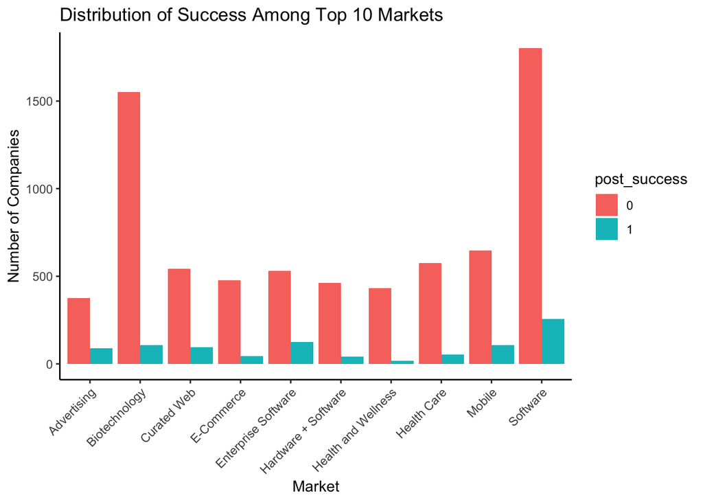

```r
ggplot(data = d, aes(x=market, fill = post_success)) +
  theme_classic() +
  ggtitle("Distribution of Success Among Top 10 Markets") +
  xlab("Market") +
  ylab("Number of Companies") +
  geom_bar(position="dodge") +
  theme(axis.text.x = element_text(angle = 45, hjust = 1))
```

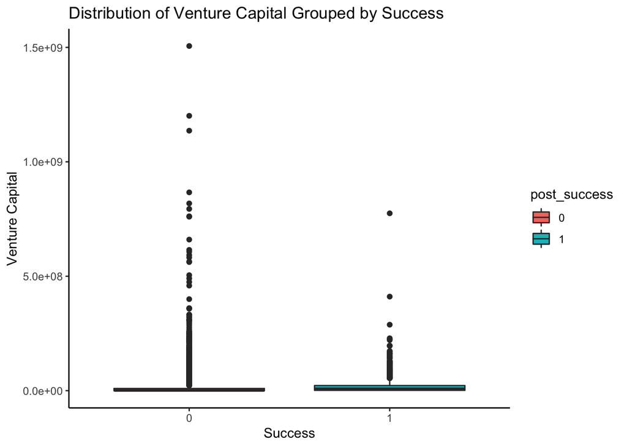

```r
ggplot(data=dat, aes(x=post_success, y=venture, fill = post_success)) +
  theme_classic() +
  geom_boxplot() +
  ggtitle("Distribution of Venture Capital Grouped by Success") +
  xlab("Success") +
  ylab("Venture Capital")
```

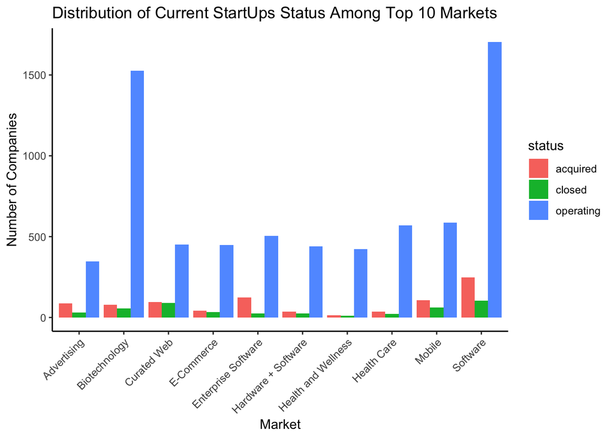

```r
ggplot(data = d, aes(x=market, fill = status)) +
  theme_classic() +
  ggtitle("Distribution of Current StartUps Status Among Top 10 Markets") +
  xlab("Market") +
  ylab("Number of Companies") +
  geom_bar(position="dodge") +
  theme(axis.text.x = element_text(angle = 45, hjust = 1))
```

```r
d1 = subset(d, d$founded_year == 2000:2014)
d1
```

|  | market | post_success | status | founded_year |
| --- | --- | --- | --- | --- |
| 10 | E-Commerce | 0 | operating | 2001 |
| 65 | Software | 0 | operating | 2008 |
| 112 | Health and Wellness | 0 | operating | 2009 |
| 146 | Advertising | 0 | operating | 2004 |
| 147 | Hardware + Software | 0 | operating | 2005 |
| 250 | Software | 0 | operating | 2013 |
| 268 | Curated Web | 0 | operating | 2008 |
| 327 | Software | 0 | operating | 2001 |
| 351 | Biotechnology | 0 | operating | 2011 |
| 401 | Health Care | 0 | operating | 2013 |

[output cut: 456 more lines]

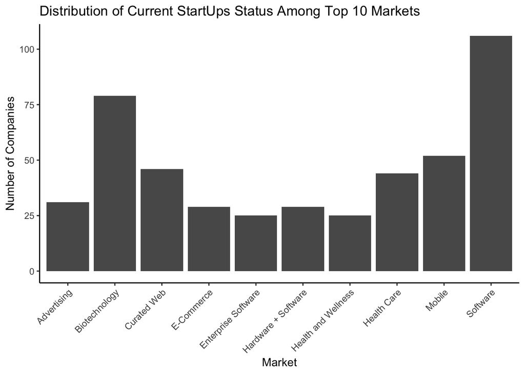

```r
ggplot(data = d1, aes(x=market, fill = founded_year)) +
  theme_classic() +
  ggtitle("Distribution of Current StartUps Status Among Top 10 Markets") +
  xlab("Market") +
  ylab("Number of Companies") +
  geom_bar(position="dodge") +
  theme(axis.text.x = element_text(angle = 45, hjust = 1))
```

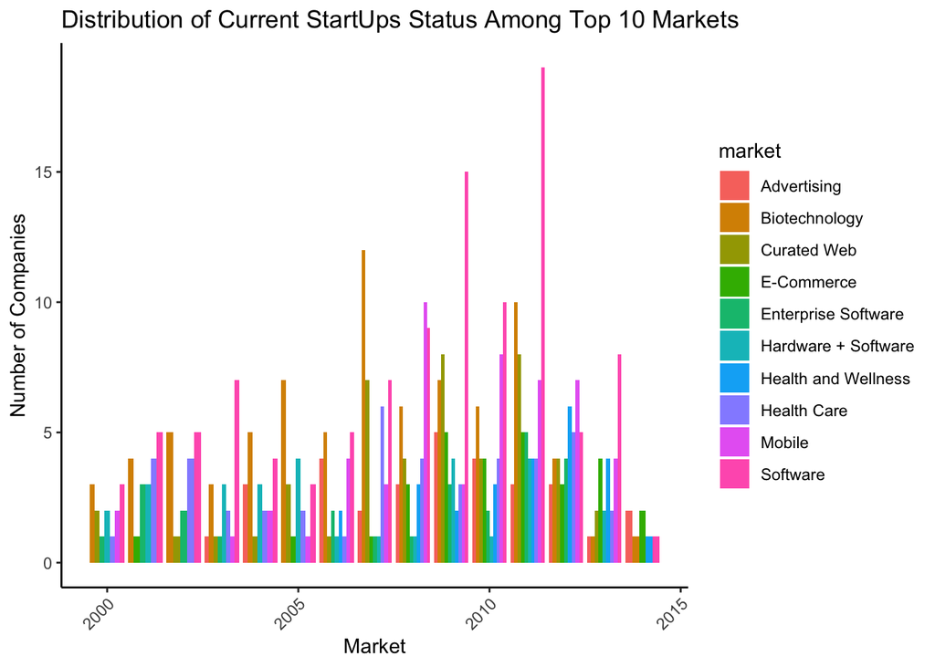

```r
ggplot(data = d1, aes(x=founded_year, fill = market)) +
  theme_classic() +
  ggtitle("Distribution of Current StartUps Status Among Top 10 Markets") +
  xlab("Market") +
  ylab("Number of Companies") +
  geom_bar(position="dodge") +
  theme(axis.text.x = element_text(angle = 45, hjust = 1))
```

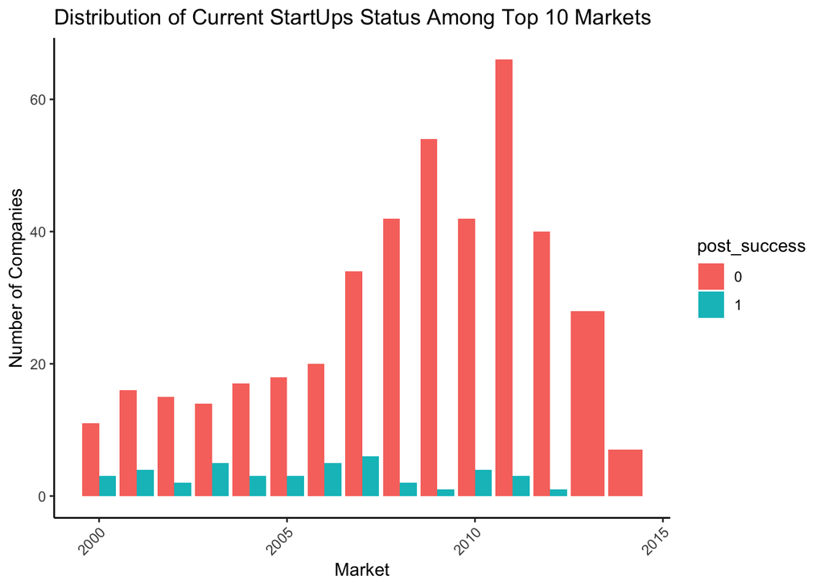

```r
ggplot(data = d1, aes(x=founded_year, fill = post_success)) +
  theme_classic() +
  ggtitle("Distribution of Current StartUps Status Among Top 10 Markets") +
  xlab("Market") +
  ylab("Number of Companies") +
  geom_bar(position="dodge") +
  theme(axis.text.x = element_text(angle = 45, hjust = 1))
```

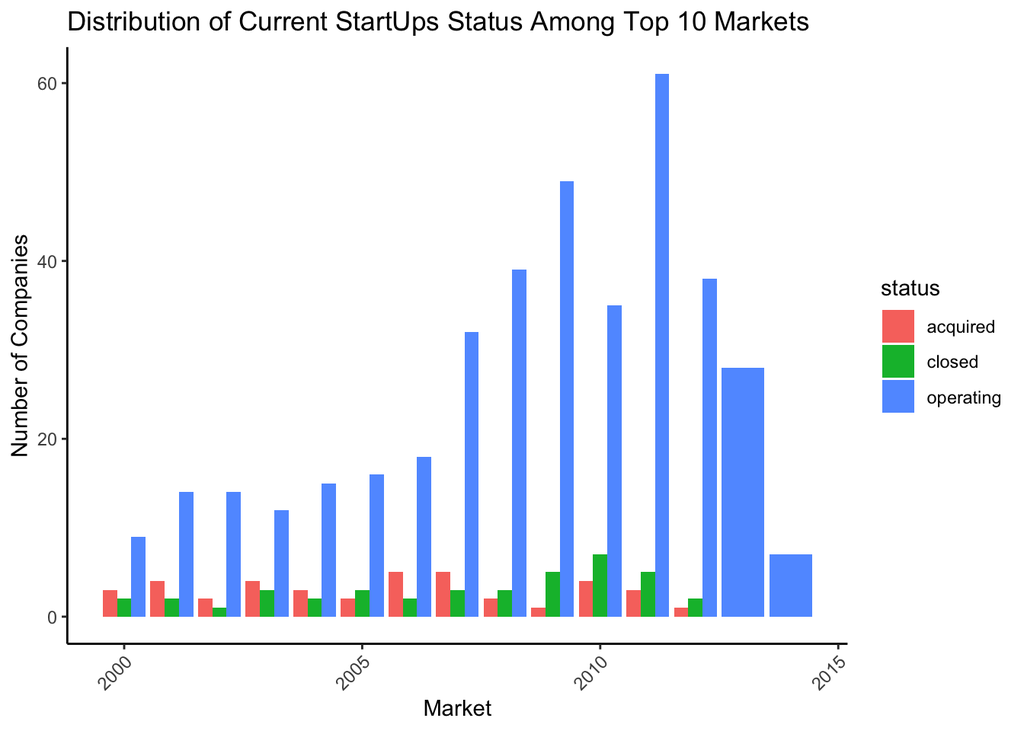

```r
ggplot(data = d1, aes(x=founded_year, fill = status)) +
  theme_classic() +
  ggtitle("Distribution of Current StartUps Status Among Top 10 Markets") +
  xlab("Market") +
  ylab("Number of Companies") +
  geom_bar(position="dodge") +
  theme(axis.text.x = element_text(angle = 45, hjust = 1))
```

```r
d2 = subset(dat, dat$founded_year == 2000:2014)
```

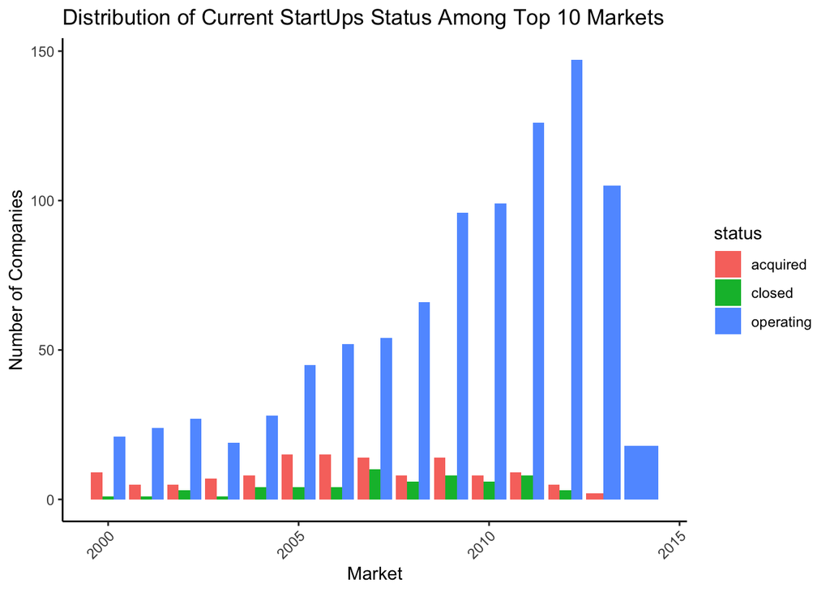

```r
ggplot(data = d2, aes(x=founded_year, fill = status)) +
  theme_classic() +
  ggtitle("Distribution of Current StartUps Status Among Top 10 Markets") +
  xlab("Market") +
  ylab("Number of Companies") +
  geom_bar(position="dodge") +
  theme(axis.text.x = element_text(angle = 45, hjust = 1))
```